# Rcpp

Andrea Becsek

2020-05-25

The aim of this portfolio is to demonstrate the usage of `C++` in conjunction with `R` via the `Rcpp` package. The application that we are considering is the adaptive kernel regression smoothing.

Simulate data generated by the model
$$y_i = sin(\alpha\pi x^3)+z_i, \;\; \text{where}\;z_i \sim\mathcal{N}(0,\sigma^2),$$

for $i=1, \cdots, 400$, $\alpha=4$, and $\sigma=0.2$.

```r
set.seed(42)
n <- 400
x <- runif(n)
y <- sin(4 * pi * x^3) + rnorm(n, 0, 0.2)
df <- data.frame(x = x, y = y)
```

Estimate the conditional expectation $\mu(x)=\mathbb{E}(y|x)$ using a kernel regression smoother
$$\hat{\mu}(x)=\frac{\sum_{i=1}^nk_{\lambda}(x,x_i)y_i}{\sum_{i=1}^nk_{\lambda}(x,x_i)},$$
where $\lambda>0$. The estimation is produced by using a Gaussian kernel with variance $\lambda^2$.

Let’s first implement the function in `R`:

```r
meanKRS <- function(y, x, x0, lam) {
  n <- length(x)
  n0 <- length(x0)
  out <- numeric(n0)

  # compute the estimated conditional expectation
  for (i in 1:n0) {
    kernel <- dnorm(x, x0[i], lam)
    out[i] <- sum(kernel * y) / sum(kernel)
  }

  return(out)
}
```

Use the estimator to produce two fits, for two different $\lambda$ values

```r
# test points
x_new <- seq(0, 1, length.out = 1000)

# fit estimator for large lambda
muSmoothLarge <- meanKRS(y = y, x = x, x0 = x_new, lam = 0.06)

# fit estimator for small lambda
muSmoothSmall <- meanKRS(y = y, x = x, x0 = x_new, lam = 0.02)
```

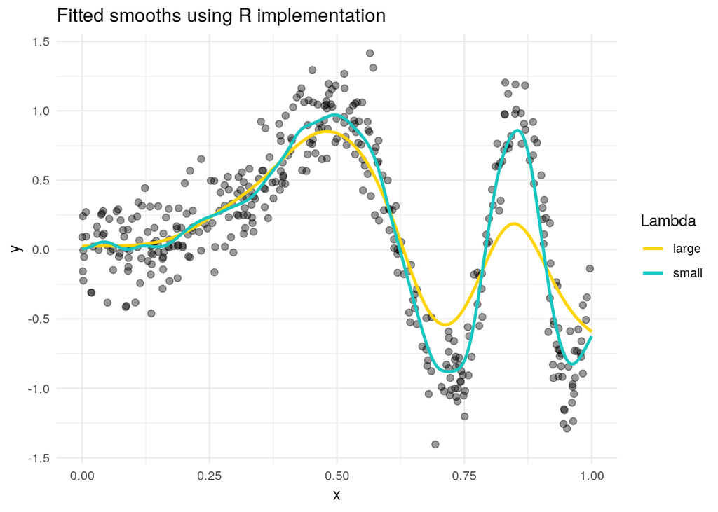